# GraceLi_A1

Grace Li

09/27/2021

# For Electrical

Read files from electricity consumption.

```r
library(tidyverse)

years <- 2017:2021
quarters <- 1:4
type <- "Electric"

pge_elec1 <- NULL

for(year in years){
  for(quarter in quarters) {
    if(year==2021){
      quarter <- 1:2
    }
    else{
      quarter <- 1:4
    }
    filename <-
      paste0(
        "pge/PGE_",
        year,
        "_Q",
        quarter,
        "_",
        type,
        "UsageByZip.csv"
      )
    print(filename)

    temp_e<- read_csv(filename)

    pge_elec1 <- rbind(pge_elec1,temp_e)

    saveRDS(pge_elec1, "pge_elec1.rds")
  }
}
```

```
## [1] "pge/PGE_2017_Q1_ElectricUsageByZip.csv"
## [2] "pge/PGE_2017_Q2_ElectricUsageByZip.csv"
## [3] "pge/PGE_2017_Q3_ElectricUsageByZip.csv"
## [4] "pge/PGE_2017_Q4_ElectricUsageByZip.csv"
## [1] "pge/PGE_2017_Q1_ElectricUsageByZip.csv"
## [2] "pge/PGE_2017_Q2_ElectricUsageByZip.csv"
## [3] "pge/PGE_2017_Q3_ElectricUsageByZip.csv"
## [4] "pge/PGE_2017_Q4_ElectricUsageByZip.csv"
## [1] "pge/PGE_2017_Q1_ElectricUsageByZip.csv"
## [2] "pge/PGE_2017_Q2_ElectricUsageByZip.csv"
## [3] "pge/PGE_2017_Q3_ElectricUsageByZip.csv"
## [4] "pge/PGE_2017_Q4_ElectricUsageByZip.csv"
## [1] "pge/PGE_2017_Q1_ElectricUsageByZip.csv"
## [2] "pge/PGE_2017_Q2_ElectricUsageByZip.csv"
## [3] "pge/PGE_2017_Q3_ElectricUsageByZip.csv"
```

[output cut: 57 more lines]

Categorize the electrical data into commercial(com) and residential(res), since we’ll be needing those for the graph.Though might be a bit complicated, perhaps use a loop? Need to ask.

```r
pge_elec_com <-
  pge_elec1 %>%
  filter(
    CUSTOMERCLASS %in%
      c(
        "Elec- Commercial"
      )
  ) %>%
  select(
    -c(COMBINED, AVERAGEKWH)
  ) %>%
  group_by(YEAR, MONTH, CUSTOMERCLASS) %>%
  summarize(
    TOTALKWH =
      sum(
        TOTALKWH,
        na.rm = T
      )
  ) %>%
  mutate(
    TOTALKBTU = TOTALKWH*3.412,
    DATE =
      paste(
        YEAR,
        MONTH,
        "01",
        sep="-"
      ) %>% as.Date()
  )

pge_elec_res <-
  pge_elec1 %>%
  filter(
    CUSTOMERCLASS %in%
      c(
        "Elec- Residential"
      )
  ) %>%
  select(
    -c(COMBINED, AVERAGEKWH)
  ) %>%
  group_by(YEAR, MONTH, CUSTOMERCLASS) %>%
  summarize(
    TOTALKWH =
      sum(
        TOTALKWH,
        na.rm = T
      )
  ) %>%
  mutate(
    TOTALKBTU = TOTALKWH*3.412,
    DATE =
      paste(
        YEAR,
        MONTH,
        "01",
        sep="-"
      ) %>% as.Date()
  )
```

# For Gas

Read file for gas.

```r
library(tidyverse)

years <- 2017:2021
quarters <- 1:4
type <- "Gas"

pge_gas1 <- NULL

for(year in years){
  for(quarter in quarters) {
    if(year==2021){
      quarter <- 1:2
    }
    else{
      quarter <- 1:4
    }
    filename <-
      paste0(
        "pge/PGE_",
        year,
        "_Q",
        quarter,
        "_",
        type,
        "UsageByZip.csv"
      )
    print(filename)

    temp_g<- read_csv(filename)

    pge_gas1 <- rbind(pge_gas1, temp_g)

    saveRDS(pge_gas1, "pge_gas1.rds")
  }
}
```

```
## [1] "pge/PGE_2017_Q1_GasUsageByZip.csv" "pge/PGE_2017_Q2_GasUsageByZip.csv"
## [3] "pge/PGE_2017_Q3_GasUsageByZip.csv" "pge/PGE_2017_Q4_GasUsageByZip.csv"
## [1] "pge/PGE_2017_Q1_GasUsageByZip.csv" "pge/PGE_2017_Q2_GasUsageByZip.csv"
## [3] "pge/PGE_2017_Q3_GasUsageByZip.csv" "pge/PGE_2017_Q4_GasUsageByZip.csv"
## [1] "pge/PGE_2017_Q1_GasUsageByZip.csv" "pge/PGE_2017_Q2_GasUsageByZip.csv"
## [3] "pge/PGE_2017_Q3_GasUsageByZip.csv" "pge/PGE_2017_Q4_GasUsageByZip.csv"
## [1] "pge/PGE_2017_Q1_GasUsageByZip.csv" "pge/PGE_2017_Q2_GasUsageByZip.csv"
## [3] "pge/PGE_2017_Q3_GasUsageByZip.csv" "pge/PGE_2017_Q4_GasUsageByZip.csv"
## [1] "pge/PGE_2018_Q1_GasUsageByZip.csv" "pge/PGE_2018_Q2_GasUsageByZip.csv"
## [3] "pge/PGE_2018_Q3_GasUsageByZip.csv" "pge/PGE_2018_Q4_GasUsageByZip.csv"
## [1] "pge/PGE_2018_Q1_GasUsageByZip.csv" "pge/PGE_2018_Q2_GasUsageByZip.csv"
## [3] "pge/PGE_2018_Q3_GasUsageByZip.csv" "pge/PGE_2018_Q4_GasUsageByZip.csv"
## [1] "pge/PGE_2018_Q1_GasUsageByZip.csv" "pge/PGE_2018_Q2_GasUsageByZip.csv"
## [3] "pge/PGE_2018_Q3_GasUsageByZip.csv" "pge/PGE_2018_Q4_GasUsageByZip.csv"
## [1] "pge/PGE_2018_Q1_GasUsageByZip.csv" "pge/PGE_2018_Q2_GasUsageByZip.csv"
```

[output cut: 21 more lines]

For the following chunk, I assume it should be same as the electrical above, probably need a loop, but not sure how. Need further improvement.

```r
pge_gas_com <-
  pge_gas1 %>%
  filter(
    CUSTOMERCLASS %in%
      c(
        "Gas- Commercial"
      )
  ) %>%
  select(
    -c(COMBINED, AVERAGETHM)
  ) %>%
  group_by(YEAR, MONTH, CUSTOMERCLASS) %>%
  summarize(
    TOTALTHM =
      sum(
        TOTALTHM,
        na.rm = T
      )
  ) %>%
  mutate(
    TOTALKBTU = TOTALTHM*100,
    DATE =
      paste(
        YEAR,
        MONTH,
        "01",
        sep="-"
      ) %>% as.Date()
  )

pge_gas_res <-
  pge_gas1 %>%
  filter(
    CUSTOMERCLASS %in%
      c(
        "Gas- Residential"
      )
  ) %>%
  select(
    -c(COMBINED, AVERAGETHM)
  ) %>%
  group_by(YEAR, MONTH, CUSTOMERCLASS) %>%
  summarize(
    TOTALTHM =
      sum(
        TOTALTHM,
        na.rm = T
      )
  ) %>%
  mutate(
    TOTALKBTU = TOTALTHM*100,
    DATE =
      paste(
        YEAR,
        MONTH,
        "01",
        sep="-"
      ) %>% as.Date()
  )
```

Bind gas and elec data together and create the datasets “monthly commercial gas and electricity usage” and “monthly residential gas and electricity usage”

```r
pge_com_final <- rbind(pge_gas_com, pge_elec_com)
pge_res_final <- rbind(pge_gas_res, pge_elec_res)

saveRDS(pge_com_final, "pge_com_final.rds")
saveRDS(pge_res_final, "pge_res_final.rds")
```

# Plot graph for commercial.

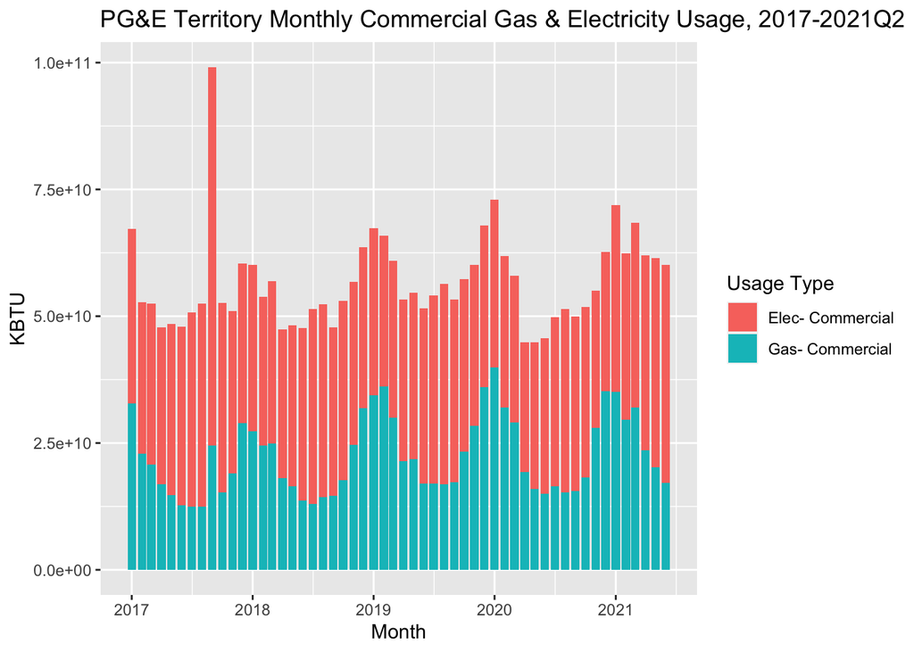

```r
library(tidyverse)
library(plotly)

pge_chart_com <-
  pge_com_final %>%
  ggplot() +
  geom_bar(
    aes(
      x = DATE,
      y = TOTALKBTU,
      fill = CUSTOMERCLASS
    ),
    stat = "identity",
    position = "stack"
  ) +
  labs(
    x = "Month",
    y = "KBTU",
    title = "PG&E Territory Monthly Commercial Gas & Electricity Usage, 2017-2021Q2",
    fill = "Usage Type"
  )
pge_chart_com
```

# Plot graph for residential.

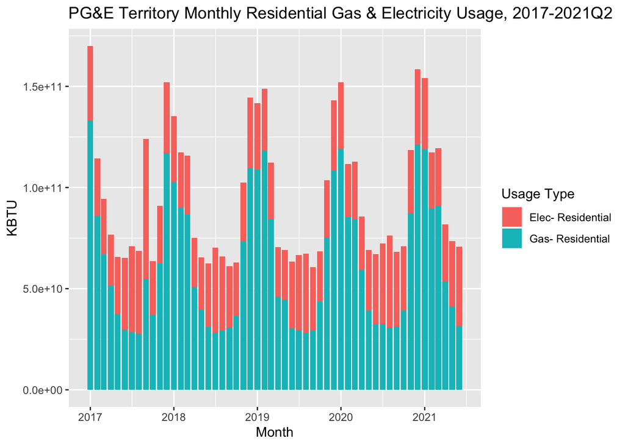

```r
library(tidyverse)
library(plotly)

pge_chart_res <-
  pge_res_final %>%
  ggplot() +
  geom_bar(
    aes(
      x = DATE,
      y = TOTALKBTU,
      fill = CUSTOMERCLASS
    ),
    stat = "identity",
    position = "stack"
  ) +
  labs(
    x = "Month",
    y = "KBTU",
    title = "PG&E Territory Monthly Residential Gas & Electricity Usage, 2017-2021Q2",
    fill = "Usage Type"
  )
pge_chart_res
```

# Reflections

For commercial monthly gas and electricity usage, we can see an all-time low at April, 2020, just when the pandemic was starting to fully spread across the country. It then slowly begins to climb up, as companies an stores adjusted to this new norm and reopened.

For residential monthly gas and electricity usage, we can see that the trend has not very much altered from 2017 to 2021, with the winter months having highest total usage that mostly contributed to a surge in gas.